# Recommendations Using my Spotify Playlists

**Justin Zhao**

## Introduction

Music has been a universal part of human culture for tens of thousands of years. However, in recent times it has been more and more accessible to us. Let's look at the formats of music throughout recent history.

Starting in 1877, the phonograph was invented by Thomas Edison. This marked the first time that people could listen to music in the comfort of their own homes. It was also the first time that music could be sold in a physical format.

Next up came the vinyl record in 1948, this allowed for multiple songs on one record. It remained a dominant recording format for the rest of the 20th century.

Then came the RCA magnetic tape in 1958, which wasn't as popular as vinyl, but could be used in cars. For the first time, driving down the interstate listening to the Beatles was possible. Then, came an explosion of different music formats.

In 1981, the Sony Walkman was introduced. For the first time, listeners could listen to music whenever and wherever.

In 1982, the CD was made available. These became the dominant format of music for around a decade.

In 1999, Napster became a popular way to download music for free.

In 2001, the Apple iPod was introduced, which further paved the way for digital forms of music.

Finally, in 2011, Spotify was released. It was the first streaming service to be able to license a vast library of music. Now, we were able to pay a fee for access to basically all of the music in the world.

Nowadays, Spotify is the most popular music streaming platform in the world, with over 350 million users and 150 million subscribers as of 2024. Spotify is known for having a recommendation system that allows you to look for new songs that you might like. However, it has recently decreased in quality. I keep on getting the same songs recommended, and would like to check out some new songs that are relevant to my music taste. Luckily, Spotify has a Web API that allows you to see attributes of any song that is in their collection of over 100 million. Using these attributes, I will walk through the 5 step process of data science:

1. Data Collection
2. Data Processing
3. Exploratory Analysis and Data Visualization
4. Model Analysis, Hypothesis Testing, and Machine Learning
5. Insight and Policy Decisions

## Imports

In this project we will use many powerful python libraries. For arrays and math, we will use NumPy.

For manipulating tabular data, we will use pandas.

For plotting graphs and charts, we will use matplotlib.

For machine learning, we will use sklearn.

For getting my Spotify data, we will use spotipy.

You can see more information and the documentation for each library below. Feel free to refer to these for additional features and applications of these tools.

- [NumPy](https://numpy.org/doc/stable/)
- [pandas](https://pandas.pydata.org/docs/)
- [matplotlib](https://matplotlib.org/stable/index.html)
- [seaborn](https://seaborn.pydata.org/)
- [sklearn](https://scikit-learn.org/0.21/documentation.html)
- [spotipy](https://spotipy.readthedocs.io/en/2.22.1/#)
- [Spotify Web API](https://developer.spotify.com/documentation/web-api)

```python
import numpy as np
import pandas as pd
import matplotlib.pyplot as plt
import seaborn as sns
from sklearn.cluster import KMeans
from sklearn.decomposition import PCA
from sklearn.preprocessing import StandardScaler
from sklearn.neighbors import NearestNeighbors
import spotipy
from spotipy.oauth2 import SpotifyOAuth
import os
import time
```

## Data Collection

Data collection is obtaining raw data. This can be from various sources such as databases, sensors, files, Application Programming Interface (APIs), or web scraping.

In this project we will use spotipy, a useful Python library for the Spotify Web API, to collect my playlists and every single song that appears on them. We will create a Pandas Dataframe with the attributes and features of each song.

First, we need to connect to my Spotify account using spotipy. You can use your own account using this [guide](https://developer.spotify.com/documentation/web-api/tutorials/getting-started). After you have access to the client credentials, just input in this code here (assuming you are working in jupyter notebook) to hide them using environment variables.

```python
os.environ['SPOTIPY_CLIENT_ID'] = 'your_client_id'
os.environ['SPOTIPY_CLIENT_SECRET'] = 'your_client_secret'
os.environ['SPOTIPY_REDIRECT_URI'] = 'your_redirect_uri'
```

```python
# Create Spotify API link
SPOTIPY_CLIENT_ID = os.environ['SPOTIPY_CLIENT_ID']
SPOTIPY_CLIENT_SECRET = os.environ['SPOTIPY_CLIENT_SECRET']
SPOTIPY_REDIRECT_URI = os.environ['SPOTIPY_REDIRECT_URI']
sp = spotipy.Spotify(auth_manager=SpotifyOAuth(
    client_id=SPOTIPY_CLIENT_ID,
    client_secret=SPOTIPY_CLIENT_SECRET,
    redirect_uri=SPOTIPY_REDIRECT_URI,
    scope='playlist-read-private'
))
```

Now that we are all set up, we can collect the tracks from all of my playlists. Note that you may instead choose specific playlists or even just albums for specific artists as well, just use the documentation for [spotipy](https://spotipy.readthedocs.io/en/2.22.1/#).

#### Warning: This code will make your browser repeatedly open and close an authentication tab until your playlists are fully collected. This is normal and should take less than a minute.

```python
# Collect my playlists
def get_user_playlists(sp):
    playlists = []
    results = sp.current_user_playlists()
    while results:
        playlists.extend(results['items'])
        results = sp.next(results) if results['next'] else None
    return playlists

playlists = get_user_playlists(sp)

# Collect all tracks from my playlists
def get_playlist_tracks(sp, playlist_id):
    tracks = []
    results = sp.playlist_tracks(playlist_id)
    while results:
        tracks.extend(results['items'])
        results = sp.next(results) if results['next'] else None
    return tracks

all_tracks = []
for playlist in playlists:
    tracks = get_playlist_tracks(sp, playlist['id'])
    all_tracks.extend(tracks)
# Get track URIs
track_uris = [track['track']['uri'] for track in all_tracks if track['track']]
```

Now we have to collect the attributes for each track.

```python
# Collect the attributes for each track
def get_track_attributes(track_uris):
    attributes = []
    for uri in track_uris:
        time.sleep(1.0)
        track = sp.track(uri)
        # Fetch audio features
        features = sp.audio_features([uri])[0]

        track_info = {
            'name': track['name'],
            'album': track['album']['name'],
            'artist': ', '.join(artist['name'] for artist in track['artists']),
            'release_date': track['album']['release_date'],
            'duration_ms': track['duration_ms'],
            'popularity': track['popularity'],
            'uri': track['uri'],
            'danceability': features['danceability'],
            'energy': features['energy'],
            'key': features['key'],
            'loudness': features['loudness'],
            'mode': features['mode'],
            'speechiness': features['speechiness'],
            'acousticness': features['acousticness'],
            'instrumentalness': features['instrumentalness'],
            'liveness': features['liveness'],
            'valence': features['valence'],
            'tempo': features['tempo']
        }
        attributes.append(track_info)
    return attributes
```

```python
track_attributes = get_track_attributes(track_uris)
```

We turn it into a pandas Dataframe so that we can perform table operations on it.

```python
df = pd.DataFrame(track_attributes)
```

Convert to csv so that we don't have to ever go through that ever again, we can just use the pandas read_csv function on the saved csv file.

```python
df.to_csv('track_attributes_with_audio_features.csv', index=False)
```

## Data Processing

Data processing refers to the manipulation and transformation of raw data into a more useful format, making it suitable for analysis, visualization, or other applications. It includes processes such as handling missing values, outlier detection and removal, data standardization, data transformation, feature engineering, and encoding categorical variables. For this project, we will be converting the dates into datetime objects, removing duplicates, and checking for missing values.

```python
df = pd.read_csv('track_attributes_with_audio_features.csv')
```

Let's see how our data looks like!!

```python
df.head()
```

[output not shown]

I have some duplicate songs in my playlists, so we can drop them using the name. It's better than dropping using the URI because some songs have different versions.

```python
df = df.drop_duplicates(subset=['name'])
```

Let's convert the release dates into datetime objects so they can be used in graphs.

```python
df['release_date'] = pd.to_datetime(df['release_date'], errors='coerce', format='ISO8601')
```

Let's check if it worked! The release date should be a datetime object.

```python
print(df.dtypes)
```

```
name                        object
album                       object
artist                      object
release_date        datetime64[ns]
duration_ms                  int64
popularity                   int64
uri                         object
danceability               float64
energy                     float64
key                          int64
loudness                   float64
mode                         int64
speechiness                float64
acousticness               float64
instrumentalness           float64
liveness                   float64
valence                    float64
tempo                      float64
cluster                      int64
dtype: object
```

We can also check to see whether there are any missing values in our dataframe using this code.

```python
nan_count_per_column = df.isna().sum()
print(nan_count_per_column)
```

```
name                0
album               0
artist              0
release_date        0
duration_ms         0
popularity          0
uri                 0
danceability        0
energy              0
key                 0
loudness            0
mode                0
speechiness         0
acousticness        0
instrumentalness    0
liveness            0
valence             0
tempo               0
cluster             0
dtype: int64
```

Looks good! Now let's move on to analysis and data visualization!

## Exploratory Analysis and Data Visualization

Let's first get a idea of the data that we are working with.

```python
print(df.describe())
```

[output not shown]

This shows the means and medians, as well as other statistics that could be used for analysis.

Histograms provide a visual representation of the data's distribution, allowing you to quickly identify patterns such as normal distribution, skewness, or bimodality.

Let's take a look at histograms for all of our features.

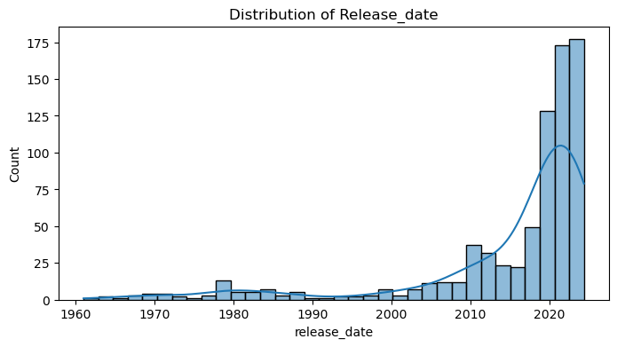

```python
feature = 'release_date'
plt.figure(figsize=(8, 4))
sns.histplot(df[feature], kde=True)
plt.title(f'Distribution of {feature.capitalize()}')
plt.show()
```

We can see that most of my songs are released after 2010. This graph is skewed left, so I should use the median as the center.

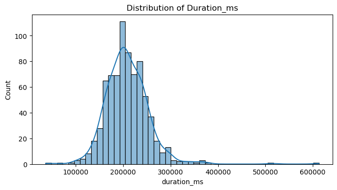

```python
feature = 'duration_ms'
plt.figure(figsize=(8, 4))
sns.histplot(df[feature], kde=True)
plt.title(f'Distribution of {feature.capitalize()}')
plt.show()
```

This graph shows that my songs are generally about 200 seconds long, or 3 minutes and 20 seconds long. It is also a pretty symmetrical distribution.

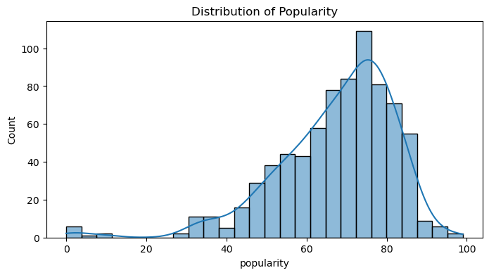

```python
feature = 'popularity'
plt.figure(figsize=(8, 4))
sns.histplot(df[feature], kde=True)
plt.title(f'Distribution of {feature.capitalize()}')
plt.show()
```

This graph shows that I mostly listen to 'popular' music.

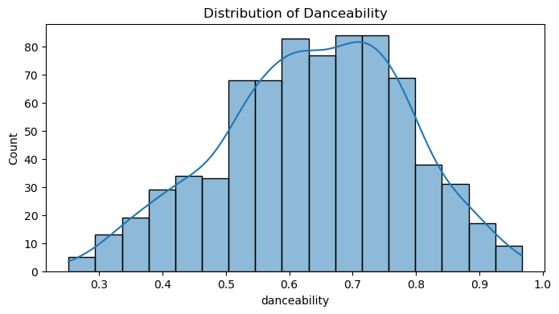

```python
feature = 'danceability'
plt.figure(figsize=(8, 4))
sns.histplot(df[feature], kde=True)
plt.title(f'Distribution of {feature.capitalize()}')
plt.show()
```

According to the Spotify API, Danceability describes how suitable a track is for dancing based on a combination of musical elements including tempo, rhythm stability, beat strength, and overall regularity. A value of 0.0 is least danceable and 1.0 is most danceable. There is a pretty symmetrical distribution of danceability, so I could say this is mostly random.

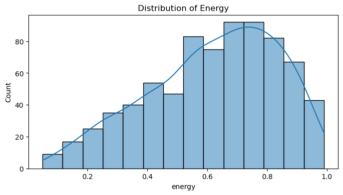

```python
feature = 'energy'
plt.figure(figsize=(8, 4))
sns.histplot(df[feature], kde=True)
plt.title(f'Distribution of {feature.capitalize()}')
plt.show()
```

According to the Spotify API, Energy is a measure from 0.0 to 1.0 and represents a perceptual measure of intensity and activity. Typically, energetic tracks feel fast, loud, and noisy. For example, death metal has high energy, while a Bach prelude scores low on the scale. Perceptual features contributing to this attribute include dynamic range, perceived loudness, timbre, onset rate, and general entropy. The energy distribution is mostly on the higher side, so I can say that I listen to more energetic music.

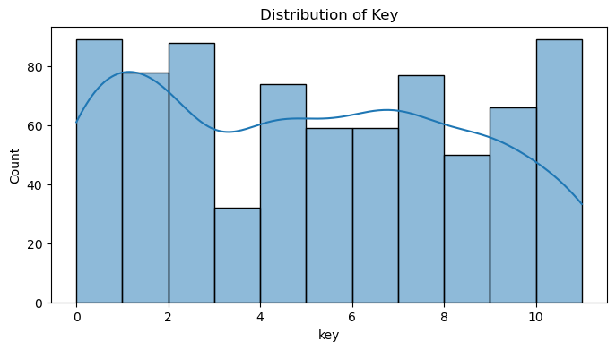

```python
feature = 'key'
plt.figure(figsize=(8, 4))
sns.histplot(df[feature], kde=True)
plt.title(f'Distribution of {feature.capitalize()}')
plt.show()
```

According to the Spotify API, this integer represents the key the track is in. Integers map to pitches using standard Pitch Class notation. E.g. 0 = C, 1 = C♯/D♭, 2 = D, and so on. This graph doesn't mean much, as the key of most songs should be generally random. I do see a noticeable dip in the integer 3, key of D-sharp or E-flat, so maybe I don't like this key as much.

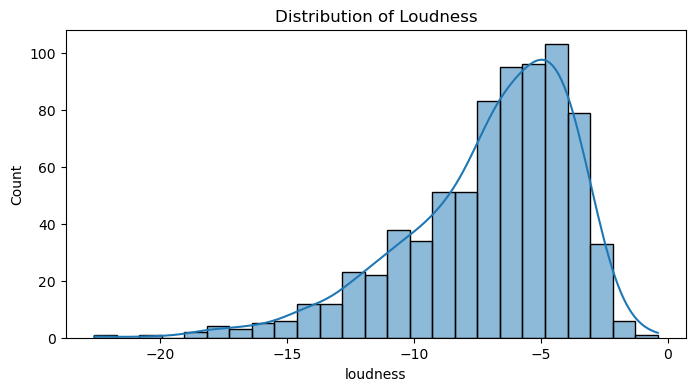

```python
feature = 'loudness'
plt.figure(figsize=(8, 4))
sns.histplot(df[feature], kde=True)
plt.title(f'Distribution of {feature.capitalize()}')
plt.show()
```

According to the Spotify API, this feature represents the overall loudness of a track in decibels (dB). Loudness values are averaged across the entire track and are useful for comparing relative loudness of tracks. Loudness is the quality of a sound that is the primary psychological correlate of physical strength (amplitude). Values typically range between -60 and 0 db. The graph shows that most of my music is at around -5 db.

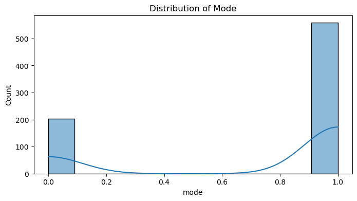

```python
feature = 'mode'
plt.figure(figsize=(8, 4))
sns.histplot(df[feature], kde=True)
plt.title(f'Distribution of {feature.capitalize()}')
plt.show()
```

According to the Spotify API, mode indicates the modality (major or minor) of a track, the type of scale from which its melodic content is derived. Major is represented by 1 and minor is 0. I listen to mostly major modalities.

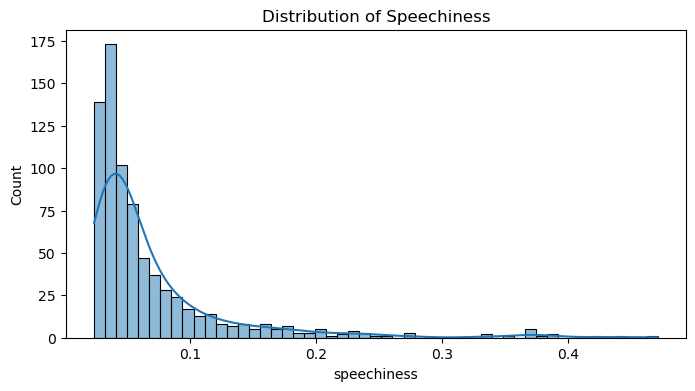

```python
feature = 'speechiness'
plt.figure(figsize=(8, 4))
sns.histplot(df[feature], kde=True)
plt.title(f'Distribution of {feature.capitalize()}')
plt.show()
```

According to the Spotify API, speechiness detects the presence of spoken words in a track. The more exclusively speech-like the recording (e.g. talk show, audio book, poetry), the closer to 1.0 the attribute value. Values above 0.66 describe tracks that are probably made entirely of spoken words. Values between 0.33 and 0.66 describe tracks that may contain both music and speech, either in sections or layered, including such cases as rap music. Values below 0.33 most likely represent music and other non-speech-like tracks. From the graph, it seems that I do not enjoy speechiness in my music.

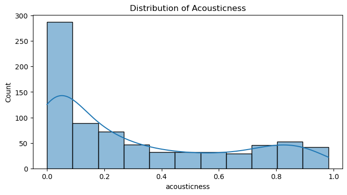

```python
feature = 'acousticness'
plt.figure(figsize=(8, 4))
sns.histplot(df[feature], kde=True)
plt.title(f'Distribution of {feature.capitalize()}')
plt.show()
```

According to the Spotify API, acousticness is a confidence measure from 0.0 to 1.0 of whether the track is acoustic. 1.0 represents high confidence the track is acoustic. I seem to like some acoustic music.

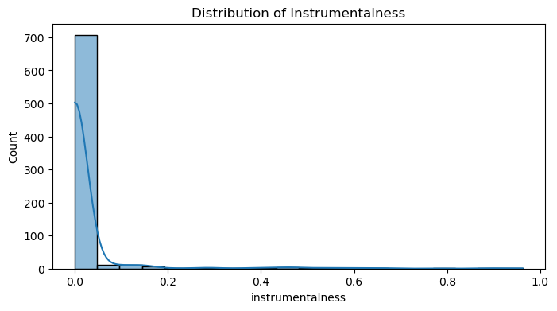

```python
feature = 'instrumentalness'
plt.figure(figsize=(8, 4))
sns.histplot(df[feature], kde=True, bins=20)
plt.title(f'Distribution of {feature.capitalize()}')
plt.show()
```

According to the Spotify API, instrumentalness predicts whether a track contains no vocals. "Ooh" and "aah" sounds are treated as instrumental in this context. Rap or spoken word tracks are clearly "vocal". The closer the instrumentalness value is to 1.0, the greater likelihood the track contains no vocal content. Values above 0.5 are intended to represent instrumental tracks, but confidence is higher as the value approaches 1.0. This shows that I generally like vocals in my music.

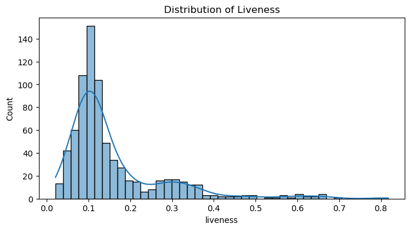

```python
feature = 'liveness'
plt.figure(figsize=(8, 4))
sns.histplot(df[feature], kde=True)
plt.title(f'Distribution of {feature.capitalize()}')
plt.show()
```

According to the Spotify API, liveness detects the presence of an audience in the recording. Higher liveness values represent an increased probability that the track was performed live. A value above 0.8 provides strong likelihood that the track is live. I don't generally like live music in my playlists.

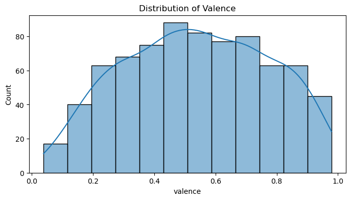

```python
feature = 'valence'
plt.figure(figsize=(8, 4))
sns.histplot(df[feature], kde=True)
plt.title(f'Distribution of {feature.capitalize()}')
plt.show()
```

According to the Spotify API, valence is a measure from 0.0 to 1.0 describing the musical positiveness conveyed by a track. Tracks with high valence sound more positive (e.g. happy, cheerful, euphoric), while tracks with low valence sound more negative (e.g. sad, depressed, angry). I seem to have a pretty normal distribution, with both sad and happy songs.

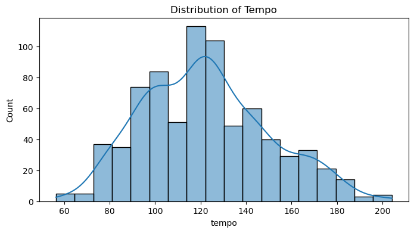

```python
feature = 'tempo'
plt.figure(figsize=(8, 4))
sns.histplot(df[feature], kde=True)
plt.title(f'Distribution of {feature.capitalize()}')
plt.show()
```

According to the Spotify API, this is the overall estimated tempo of a track in beats per minute (BPM). In musical terminology, tempo is the speed or pace of a given piece and derives directly from the average beat duration. I seem to enjoy songs that are around 120 BPM.

Next, we'll take a look at scatter plots, to explore relationships between different pairs of features.

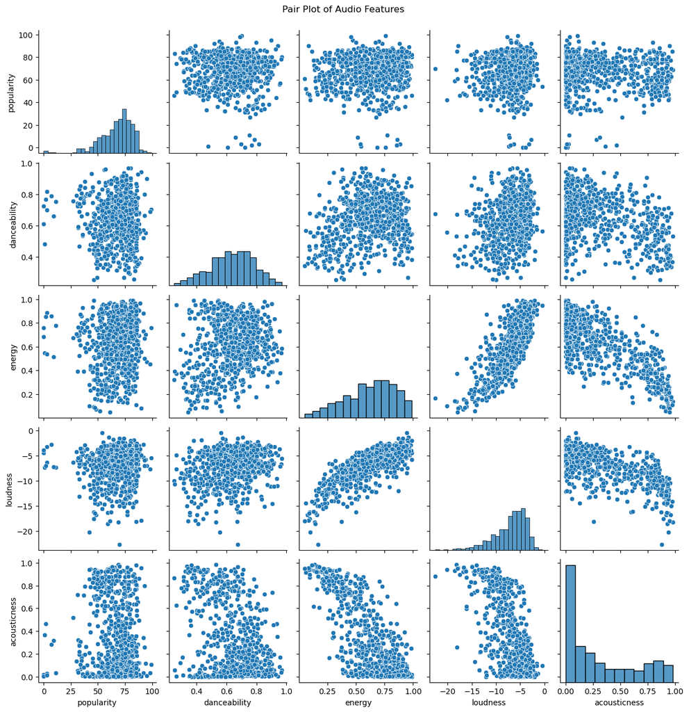

```python
# Scatter plots
sns.pairplot(df[['popularity', 'danceability', 'energy', 'loudness', 'acousticness']])
plt.suptitle('Pair Plot of Audio Features', y=1.02)
plt.show()
```

Looking at these scatter plots, we can see that there seems to be a positive relationship between energy and loudness, which makes sense in music.

## Model Analysis, Hypothesis Testing, and Machine Learning

Model analysis refers to the evaluation and assessment of predictive or descriptive models to understand their performance, strengths, weaknesses, and suitability for a particular task or problem domain.

Hypothesis testing is a statistical method used to make inferences about a population parameter based on sample data. It involves formulating a hypothesis, collecting data, and using statistical tests to determine whether the observed results are statistically significant.

Machine learning is a subset of artificial intelligence (AI) that focuses on the development of algorithms and models that enable computers to learn from and make predictions or decisions based on data without being explicitly programmed.

For this project we will use K-means clustering, which is a popular unsupervised machine learning algorithm used for partitioning a dataset into distinct groups (clusters) based on feature similarity. In this example, we start with a random initial state and will create 10 clusters based on the following features: popularity, danceability, energy, key, speechiness, acousticness, instrumentalness, liveness, valence, and tempo.

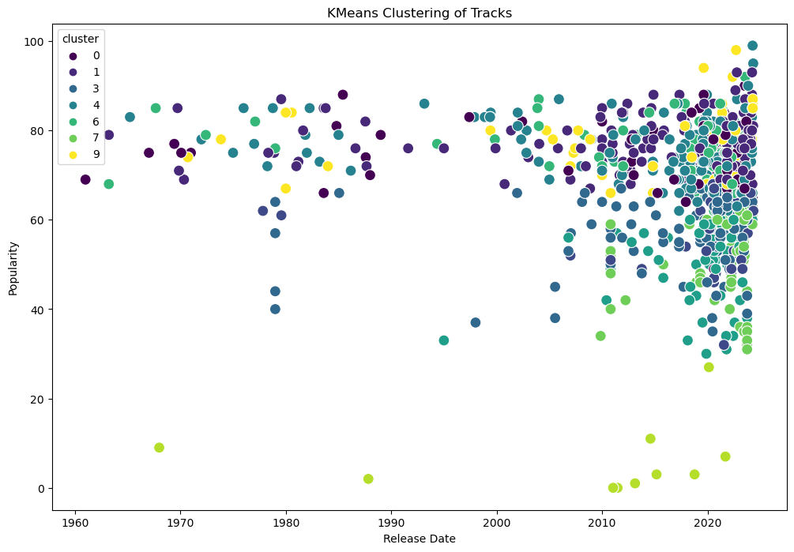

```python
X = df[['popularity', 'danceability', 'energy', 'key', 'speechiness', 'acousticness', 'instrumentalness', 'liveness','valence', 'tempo']]

# Apply KMeans clustering
kmeans = KMeans(n_clusters=10, random_state=0)
df['cluster'] = kmeans.fit_predict(X)

# Visualize clusters
plt.figure(figsize=(12, 8))
sns.scatterplot(data=df, x='release_date', y='popularity', hue='cluster', palette='viridis', s=100)
plt.title('KMeans Clustering of Tracks')
plt.xlabel('Release Date')
plt.ylabel('Popularity')
plt.show()
```

Finally, let's attempt to do our recommendation algorithm using K-Nearest Neighbors.

K-Nearest Neighbors (KNN) is a simple and intuitive supervised machine learning algorithm used for classification and regression tasks. It is a non-parametric and instance-based learning algorithm, meaning it makes predictions based on the similarity of new data points to existing data points in the training dataset. In this example we will use several features to determine the distance between each song and choose the 5 smallest distances for our recommendations.

```python
feature_columns = ['danceability', 'energy', 'key', 'loudness', 'mode', 'speechiness', 'acousticness', 'instrumentalness', 'liveness', 'valence', 'tempo']
X = df[feature_columns]

# Standardize the features
scaler = StandardScaler()
X_scaled = scaler.fit_transform(X)

# Fit Nearest Neighbors model
nbrs = NearestNeighbors(n_neighbors=5, algorithm='ball_tree').fit(X_scaled)

# Function to find similar songs
def find_similar_songs(target_uri):
    target_features = sp.audio_features([target_uri])[0]
    target_vector = scaler.transform([[target_features[feature] for feature in feature_columns]])
    distances, indices = nbrs.kneighbors(target_vector)
    similar_songs = df.iloc[indices[0]].copy()
    similar_songs['distance'] = distances[0]
    return similar_songs

# Example usage with Never Gonna Give You Up - Risk Astley
target_uri = 'spotify:track:4uLU6hMCjMI75M1A2tKUQC'
similar_songs = find_similar_songs(target_uri)
print(similar_songs[['name', 'artist', 'album', 'uri', 'distance']])
```

```
Couldn't read cache at: .cache
Couldn't write token to cache at: .cache
```

```
                              name               artist  \
677  Superstition - Single Version        Stevie Wonder
671             You Can Call Me Al           Paul Simon
694            Walking On Sunshine  Katrina & The Waves
50                         Hot Rod              Dayglow
678                      September   Earth, Wind & Fire

                                           album  \
677                    The Definitive Collection
671  Graceland (25th Anniversary Deluxe Edition)
694                          Katrina & The Waves
50                                    Fuzzybrain
678        The Best Of Earth, Wind & Fire Vol. 1

                                      uri  distance
677  spotify:track:1h2xVEoJORqrg71HocgqXd  1.829067
671  spotify:track:0qxYx4F3vm1AOnfux6dDxP  1.865112
694  spotify:track:05wIrZSwuaVWhcv5FfqeH0  2.038004
50   spotify:track:5euumi7eqEgmxvCIJw2pSp  2.053527
678  spotify:track:2grjqo0Frpf2okIBiifQKs  2.099760
```

As we can see, our recommendations for the given song "Never Gonna Give You Up" by Risk Astley are "Superstition" by Stevie Wonder, "You Can Call Me Al" by Paul Simon, "Walking On Sunshine" by Katrina & The Waves, "Hot Rod" by Dayglow, and "September" by Earth, Wind & Fire. We could build a recommendation engine for our playlists as well, but we would need to get the features for all of Spotify's songs in order to get distances between our songs and the vast library, which we do no have access to. However, this was a good example of the data science process.

## Insight and Policy Decisions

This is the part of the data science process that is the most important. Can we draw conclusions from this data analysis and provide something useful?

I learned a lot about my own music taste by using histograms. I can give a list of recommended songs from my playlists given any song. If I had access to the entire collection of audio features for all of the songs on Spotify, I could make a decent recommendation system.

Thank you for coming on this journey with me and I hope you have learned something!